# Application to the radiation monitoring data

> Outline
1. 摘要 Abstract
2. 資料說明 About the data
3. 小提琴圖 Violin Plot
4. 地圖 Map
5. 相關係數熱圖 Heatmap of correlaction Matrix
6. 總結Summary

# 1. 摘要 Abstract

「輻射監測數據」的目標是製定環境輻射/放射性分佈的系統數據，作為評估公共衛生的標準。以及當在發生輻射安全緊急情況的情況下，分析該數據對於維護國家安全和環境非常重要。輻射監測可以讓我們了解所在地區有多少和什麼樣的放射性物質存在，並測試用於估計人類輻射劑量的數學模型。 本計劃擷取二零一四年至二零一七年共四年環境輻射監測歷史數據進行敘述統計分析、趨勢變化分析等分析方法，找出不同的環境輻射監測站所監測到的環境輻射監測數據與不同的設立位置或監測時間的相關性，並更進一步結合空氣品質監測公開資料，與環境輻射監測數據是否有關。

The study of Radiation Monitoring Data can help to develop systematic data on environmental radiation/radioactivity distribution as a criterion for assessing public health. And in the event of a radiation safety emergency, the analysis of the data is important for maintaining national security and the environment. Radiation monitoring allows us to understand how much and what kind of radioactive material is present in the area and to test the mathematical model used to estimate the dose of human radiation. The project aims to find the correlation between different locations and monitoring time through the radiation monitoring historical data from 2014 to 2017. Besides, the air quality observation data are also analyzed to find the correlation with radiation.

```r
## load reqired libraries ####
library(readxl)
library(xts)
```

```r
library(lattice)
library(ggplot2)
library(reshape2)
library(UsingR)
library(lubridate)
library(ggrepel) # 為了增加離群值標籤所增加的library
library(rgdal)#for fortify()
library(rgeos) #for fortify()
library(maptools) #for readShapeSpatial()
library(RColorBrewer) #配色用brewer.pal( 9 , "Reds" )
library(corrplot)
library(tidyr)
library(mapproj)
### loading radiation data ####
load("~/Radiation/NuclearPowerlong.RData")
#load("C:/User/Christine Liou/Documents/Nuclear-Power/RData/Air_DF_Relation.RData")
load("~/Radiation/air_nuclear_wins.RData")

### loading ggplot Chinese theme ####
mytheme <- theme_grey(base_family="STKaiti")
```

# 2. 資料說明 About the data

本計劃使用行政院原子能委員會輻射偵測中心所提供之環境輻射監測歷史數據公開資料。環境輻射監測的核設施包含核一廠、核二廠、核三廠、龍門核能電廠、核能研究所、清華大學及蘭嶼貯存場等七個設施。資料為每小時一筆資料，其單位為微西弗(µSv)。為了後續利於計算，故將全部輻射監測值統一乘於一千，換算成毫西弗(mSv)。

Based on the radiation data from the Atomic Energy Council, there are seven nuclear facilities in Taiwan. The data was hourly recorded and measured by ‘µSv’. We all transfer to ‘mSv’ to analyze.

```r
summary(DF_l)
```

```
##    rad_site              date                       rad_value
##  Length:1612944     Min.   :2013-12-31 08:00:00   Min.   : 24.00
##  Class :character   1st Qu.:2014-12-31 13:45:00   1st Qu.: 50.00
##  Mode  :character   Median :2015-12-31 19:30:00   Median : 55.00
##                     Mean   :2015-12-31 19:30:00   Mean   : 57.05
##                     3rd Qu.:2016-12-31 01:15:00   3rd Qu.: 63.00
##                     Max.   :2017-12-31 07:00:00   Max.   :216.00
##                                                   NA's   :30135
##       alt         insideOrNot
##  Min.   :  10.0   Length:1612944
##  1st Qu.:  17.0   Class :character
##  Median :  25.5   Mode  :character
##  Mean   : 137.3
##  3rd Qu.:  73.0
##  Max.   :2413.0
##
```

# 3.小提琴圖 Violin Plot

資料前處理 Data preprocessing

```r
# add interval For windows RData
# DF_l$rad_value <- as.numeric(DF_l$rad_value)
# DF$rad_value <- as.numeric(DF$rad_value)
# DF$season <- factor(DF$season,levels=c("Spring","Summer","Fall","Winter"))

# add interval For mac RData
DF_l$date_without_hour <- date(DF_l$date)
DF_l$year <- year(DF_l$date)
```

```r
DF_dailyBySite <- aggregate(rad_value ~ date_without_hour + rad_site, DF_l, FUN = sum)

DF_dailyBySite$year <- year(DF_dailyBySite$date_without_hour)
DF_dailyBySite$month <- month(DF_dailyBySite$date_without_hour)

# 比較符合當前氣候的季節月份對應(Spring: 3~5, Summer: 6~8, Fall: 9~11, Winter: 12~2)
seamon <- data.frame(month=factor(1:12), season=c('Winter', 'Winter', 'Spring', 'Spring', 'Spring', 'Summer', 'Summer', 'Summer', 'Fall', 'Fall', 'Fall', 'Winter'))

DF_dailyBySite <- merge(DF_dailyBySite, seamon, by = "month")
DF_dailyBySite$season <- factor(DF_dailyBySite$season, levels=c('Spring','Summer','Fall','Winter'))

DF_dailyBySite$DailyDoseRate <-  (DF_dailyBySite$rad_value)/24
```

根據不同的時間週期，繪製出能體現環境輻射監測值的資料分佈的小提琴圖，並且加以深入分析。

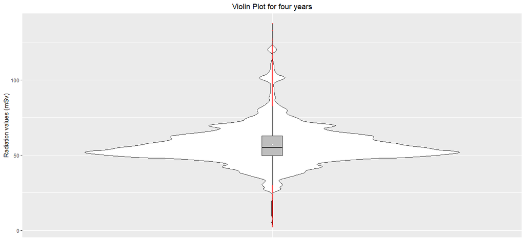

```r
ggplot(DF_dailyBySite, aes(x=factor(0), y=DailyDoseRate)) +  geom_violin() + geom_boxplot(width=.05, fill="gray", outlier.size = .5, outlier.colour = "red", na.rm = T) + stat_summary(fun.y=mean, geom="point", fill="white", shape=21, size=0.5) + mytheme + theme(axis.ticks.x = element_blank()) + theme(axis.title.x=element_blank(), axis.text.x=element_blank(), axis.ticks.x=element_blank()) +  theme(plot.title = element_text(hjust = 0.5)) + labs(y = "Radiation values (mSv)")  + ggtitle("Violin Plot for four years")
```

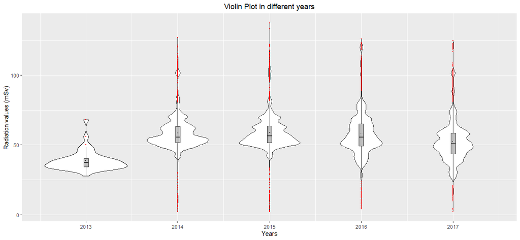

```r
ggplot(DF_dailyBySite, aes(x=year, y=DailyDoseRate, group= year)) +  geom_violin() + geom_boxplot(width=.05, fill="gray", outlier.size = .5, outlier.colour = "red", na.rm = T) + stat_summary(fun.y=mean, geom="point", fill="white", shape=21, size=0.5) + mytheme + theme(plot.title = element_text(hjust = 0.5)) + labs(y = "Radiation values (mSv)", x = "Years") + ggtitle("Violin Plot in different years")
```

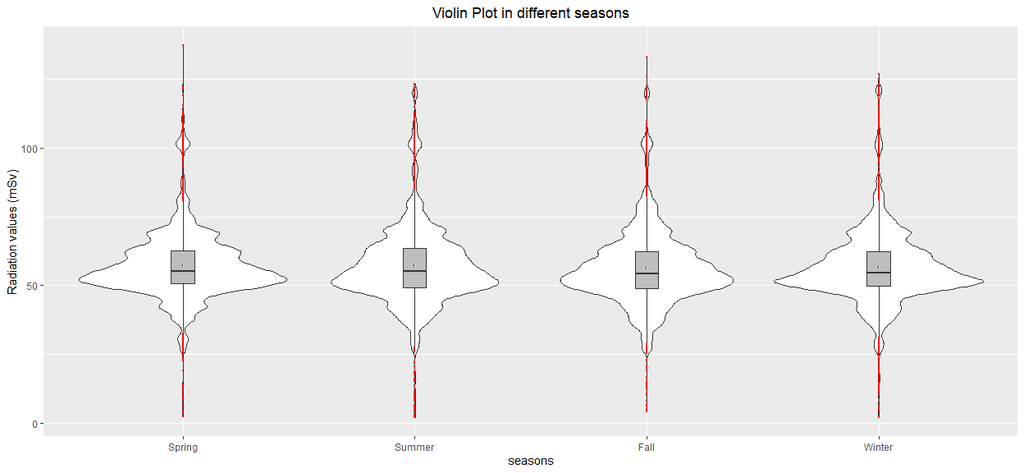

```r
ggplot(DF_dailyBySite, aes(x=season, y=DailyDoseRate, group= season)) + geom_violin() + geom_boxplot(width=.1, fill="gray", outlier.size = .5, outlier.colour = "red", na.rm = T) + stat_summary(fun.y=mean, geom="point", fill="white", shape=21, size=0.5) + mytheme + theme(plot.title = element_text(hjust = 0.5)) + labs(y = "Radiation values (mSv)", x = "seasons") + ggtitle("Violin Plot in different seasons")
```

# 4. 地圖 Map

資料前處理Data Preprocessing

```r
location <- read_excel("C:/Users/Christine Liou/Documents/Nuclear-Power/Data/station.xlsx", sheet=1)
location <- location[, c(1:3, 15)]
colnames(location) <- c("lon","lat","rad_site","id")

#空間資料檔名 請自行下載
tw_new <- readOGR(dsn = "~/Radiation/mapdata", layer = "TOWN_MOI_1071226")
tw_new.df <- fortify(tw_new, region = "TOWNID")
head(tw_new.df,10)
```

```
##        long      lat order  hole piece  id group
## 1  121.5697 25.07629     1 FALSE     1 A01 A01.1
## 2  121.5698 25.07628     2 FALSE     1 A01 A01.1
## 3  121.5699 25.07626     3 FALSE     1 A01 A01.1
## 4  121.5700 25.07622     4 FALSE     1 A01 A01.1
## 5  121.5702 25.07609     5 FALSE     1 A01 A01.1
## 6  121.5703 25.07600     6 FALSE     1 A01 A01.1
## 7  121.5704 25.07591     7 FALSE     1 A01 A01.1
## 8  121.5706 25.07574     8 FALSE     1 A01 A01.1
## 9  121.5707 25.07561     9 FALSE     1 A01 A01.1
## 10 121.5709 25.07528    10 FALSE     1 A01 A01.1
```

```r
DF_l$year <- year(DF_l$date)
DF_l$month <- month(DF_l$date)

# 比較符合當前氣候的季節月份對應(Spring: 3~5, Summer: 6~8, Fall: 9~11, Winter: 12~2)
seamon <- data.frame(month=factor(1:12), season=c('Winter', 'Winter', 'Spring', 'Spring', 'Spring', 'Summer', 'Summer', 'Summer', 'Fall', 'Fall', 'Fall', 'Winter'))
DF_l <- merge(DF_l, seamon, by = "month")

DF_inside_season=subset(DF_l, select=c('rad_site','rad_value','season'), subset=(insideOrNot == '20km以內'))
DF_outside_season=subset(DF_l, select=c('rad_site','rad_value','season'), subset=(insideOrNot == '20km以外'))

DF_inside_year=subset(DF_l, select=c('rad_site','rad_value','year'), subset=(insideOrNot == '20km以內'))
DF_outside_year=subset(DF_l, select=c('rad_site','rad_value','year'), subset=(insideOrNot == '20km以外'))
```

以環境輻射監測站設立地點為出發點，搭配台灣地圖將各測站所在的地區及其監測到的數據使用不同顏色標記，若該地區設立複數個測站，則將該地區所有測站監測到的日劑量率加總除以該地區總測站數。根據此出發點，與小提琴圖類同進行以年和季為群組進行繪圖。

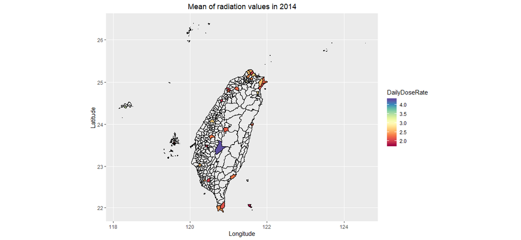

```r
twcmap_2014 <- ggplot() +
  geom_polygon(data = final2014,
               aes(x = long, y = lat,
                   group = group,
                   fill = DailyDoseRate),
               color = "black",
               size = 0.25) +
  coord_map()+#維持地圖比例
  scale_fill_gradientn(colours = brewer.pal(11,"Spectral"),na.value = NA) + mytheme + theme(plot.title = element_text(hjust = 0.5)) +
  labs(title="Mean of radiation values in 2014", x = "Longitude", y = "Latitude")
twcmap_2014
```

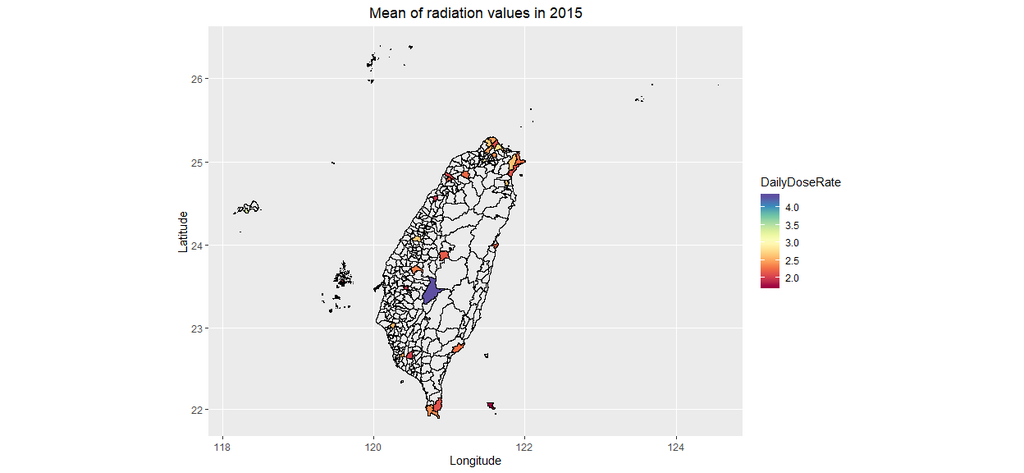

```r
twcmap_2015<-ggplot() +
  geom_polygon(data = final2015,
               aes(x = long, y = lat,
                   group = group,
                   fill = DailyDoseRate),
               color = "black",
               size = 0.25) +
  coord_map()+#維持地圖比例
  scale_fill_gradientn(colours = brewer.pal(11,"Spectral"),na.value = NA) + mytheme + theme(plot.title = element_text(hjust = 0.5)) +
  labs(title="Mean of radiation values in 2015", x = "Longitude", y = "Latitude")
twcmap_2015
```

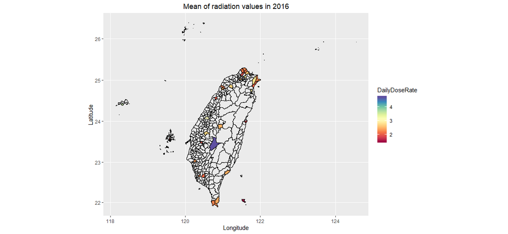

```r
twcmap_2016<-ggplot() +
  geom_polygon(data = final2016,
               aes(x = long, y = lat,
                   group = group,
                   fill = DailyDoseRate),
               color = "black",
               size = 0.25) +
  coord_map()+#維持地圖比例
  scale_fill_gradientn(colours = brewer.pal(11,"Spectral"),na.value = NA) + mytheme + theme(plot.title = element_text(hjust = 0.5)) +
  labs(title="Mean of radiation values in 2016", x = "Longitude", y = "Latitude")
twcmap_2016
```

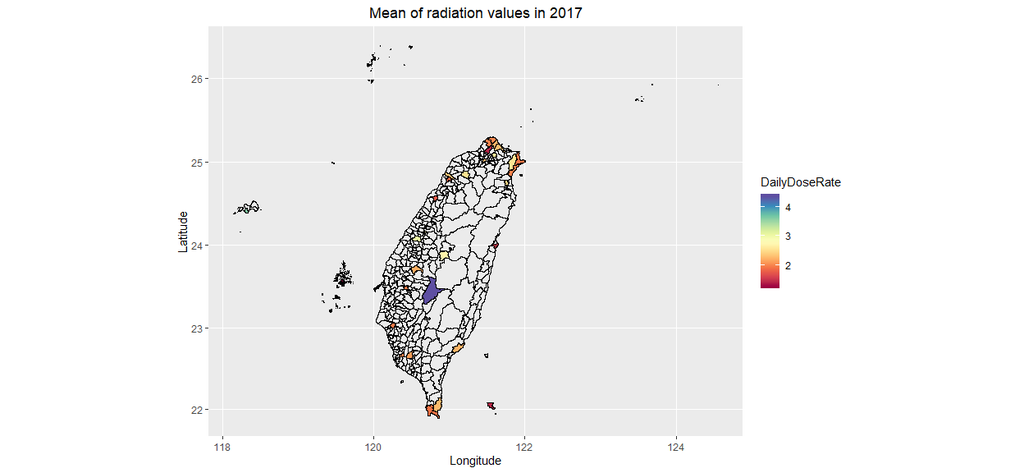

```r
twcmap_2017<-ggplot() +
  geom_polygon(data = final2017,
               aes(x = long, y = lat,
                   group = group,
                   fill = DailyDoseRate),
               color = "black",
               size = 0.25) +
  coord_map()+#維持地圖比例
  scale_fill_gradientn(colours = brewer.pal(11,"Spectral"),na.value = NA) + mytheme + theme(plot.title = element_text(hjust = 0.5)) +
  labs(title="Mean of radiation values in 2017", x = "Longitude", y = "Latitude")
twcmap_2017
```

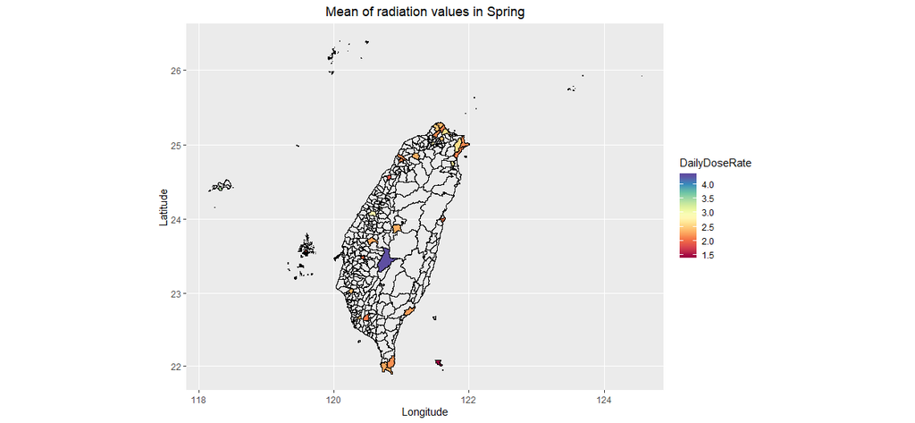

```r
twcmap_spring<-ggplot() +
  geom_polygon(data = finalSpring,
               aes(x = long, y = lat,
                   group = group,
                   fill = DailyDoseRate),
               color = "black",
               size = 0.25)  +
  coord_map() + #維持地圖比例
  scale_fill_gradientn(colours = brewer.pal(11,"Spectral"),na.value = NA) + mytheme + theme(plot.title = element_text(hjust = 0.5)) +
  labs(title="Mean of radiation values in Spring", x = "Longitude", y = "Latitude")
twcmap_spring
```

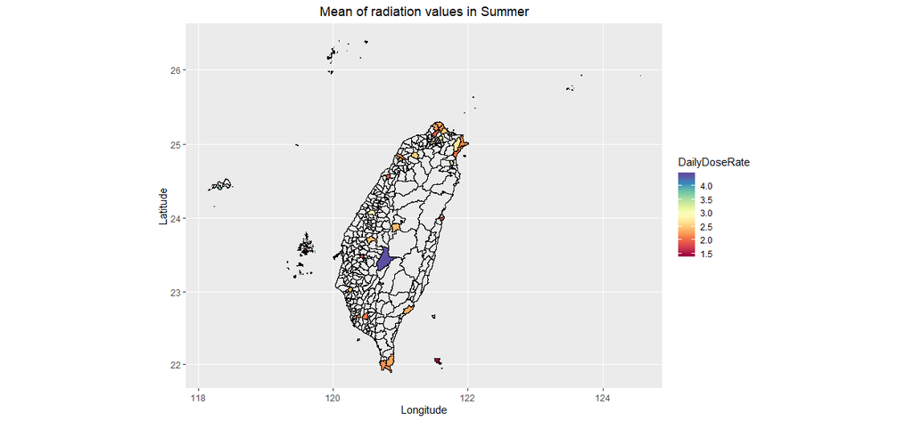

```r
twcmap_summer<-ggplot() +
  geom_polygon(data = finalSummer,
               aes(x = long, y = lat,
                   group = group,
                   fill = DailyDoseRate),
               color = "black",
               size = 0.25) +
  coord_map()+#維持地圖比例
  scale_fill_gradientn(colours = brewer.pal(11,"Spectral"),na.value = NA) + mytheme + theme(plot.title = element_text(hjust = 0.5)) +
  labs(title="Mean of radiation values in Summer", x = "Longitude", y = "Latitude")
twcmap_summer
```

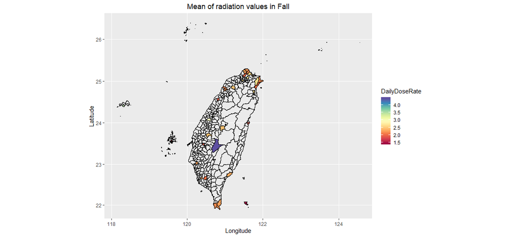

```r
twcmap_fall <- ggplot() +
  geom_polygon(data = finalFall,
               aes(x = long, y = lat,
                   group = group,
                   fill = DailyDoseRate),
               color = "black",
               size = 0.25) +
  coord_map()+#維持地圖比例
  scale_fill_gradientn(colours = brewer.pal(11,"Spectral"),na.value = NA) + mytheme + theme(plot.title = element_text(hjust = 0.5)) +
  labs(title="Mean of radiation values in Fall", x = "Longitude", y = "Latitude")
twcmap_fall
```

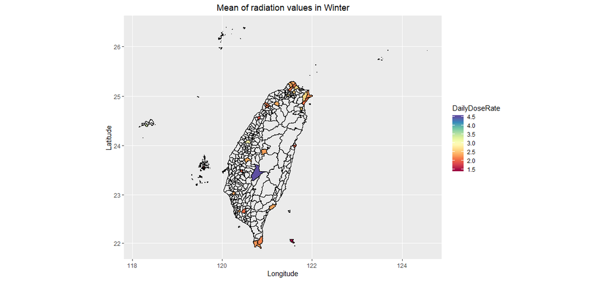

```r
twcmap_winter <- ggplot() +
  geom_polygon(data = finalWinter,
               aes(x = long, y = lat,
                   group = group,
                   fill = DailyDoseRate),
               color = "black",
               size = 0.25) +
  coord_map()+#維持地圖比例
  scale_fill_gradientn(colours = brewer.pal(11,"Spectral"),na.value = NA) + mytheme + theme(plot.title = element_text(hjust = 0.5)) +
  labs(title="Mean of radiation values in Winter", x = "Longitude", y = "Latitude")
twcmap_winter
```

# 5. 相關係數熱圖 Heatmap of correlaction Matrix

為了能更精準掌握環境輻射監測值變化的原因，本計畫增加行政院環境保護署所提供之歷年空氣品質監測公開資料，其總監測站數為七十六站，但在眾多測站中只抓取與環境輻射監測站相距半徑五公里內，符合警戒輻射範圍內的空氣品質監測站，故留下十七個與環境輻射監測站相對應的測站進行變數相關性分析。

```r
summary(Air_DF_New)
```

```
##       date                      airstation           AMB_TEMP
##  Min.   :2014-01-01 00:00:00   Length:596040      Min.   :-4.90
##  1st Qu.:2015-01-01 05:00:00   Class :character   1st Qu.:19.00
##  Median :2016-01-01 10:00:00   Mode  :character   Median :24.00
##  Mean   :2016-01-01 10:20:27                      Mean   :23.53
##  3rd Qu.:2016-12-31 17:00:00                      3rd Qu.:28.00
##  Max.   :2017-12-31 23:00:00                      Max.   :51.00
##  NA's   :68                                       NA's   :4662
##       CH4               CO              NMHC              NO
##  Min.   :1.3      Min.   :-0.020   Min.   :0.0      Min.   : -1.000
##  1st Qu.:1.8      1st Qu.: 0.200   1st Qu.:0.1      1st Qu.:  0.900
##  Median :1.9      Median : 0.290   Median :0.1      Median :  1.500
##  Mean   :1.9      Mean   : 0.333   Mean   :0.2      Mean   :  2.331
##  3rd Qu.:2.0      3rd Qu.: 0.430   3rd Qu.:0.2      3rd Qu.:  2.500
##  Max.   :6.8      Max.   : 8.520   Max.   :3.5      Max.   :177.000
##  NA's   :424424   NA's   :9168     NA's   :424424   NA's   :19940
##       NO2              NOx               O3              PM10
##  Min.   :-0.500   Min.   : -0.40   Min.   : -1.00   Min.   :   0.00
##  1st Qu.: 3.800   1st Qu.:  5.10   1st Qu.: 17.00   1st Qu.:  23.00
##  Median : 7.600   Median :  9.20   Median : 30.00   Median :  34.00
##  Mean   : 9.758   Mean   : 12.08   Mean   : 31.93   Mean   :  40.93
##  3rd Qu.:13.000   3rd Qu.: 16.00   3rd Qu.: 44.00   3rd Qu.:  52.00
##  Max.   :91.000   Max.   :215.00   Max.   :147.00   Max.   :1000.00
##  NA's   :19941    NA's   :19941    NA's   :9197     NA's   :14971
##      PM2.5            PMLv           RAINFALL             RH
##  Min.   : -4.00   low   :496663   Min.   :  0.000   Min.   :  0.00
##  1st Qu.:  8.00   medium: 56766   1st Qu.:  0.000   1st Qu.: 69.00
##  Median : 15.00   high  : 17160   Median :  0.000   Median : 78.00
##  Mean   : 19.26   danger:  7980   Mean   :  0.242   Mean   : 77.29
##  3rd Qu.: 26.00   NA's  : 17471   3rd Qu.:  0.000   3rd Qu.: 86.00
##  Max.   :423.00                   Max.   :148.000   Max.   :100.00
##  NA's   :17430                    NA's   :15139     NA's   :4497
##       SO2               THC             WD_HR         WIND_DIREC
##  Min.   : -0.500   Min.   :1.4      Min.   :  0.0   Min.   :  0.0
##  1st Qu.:  1.400   1st Qu.:1.9      1st Qu.: 58.0   1st Qu.: 59.0
##  Median :  2.000   Median :2.0      Median :141.0   Median :142.0
##  Mean   :  2.527   Mean   :2.1      Mean   :157.8   Mean   :158.4
##  3rd Qu.:  3.000   3rd Qu.:2.2      3rd Qu.:256.0   3rd Qu.:257.0
##  Max.   :119.000   Max.   :6.9      Max.   :360.0   Max.   :360.0
##  NA's   :15034     NA's   :424427   NA's   :39201   NA's   :35458
##    WIND_SPEED        WS_HR            UVB                  UVBLv
##  Min.   : 0.00   Min.   : 0.00   Min.   : 0.0     low         : 76860
##  1st Qu.: 1.30   1st Qu.: 0.80   1st Qu.: 0.0     medium      :  8964
##  Median : 2.10   Median : 1.50   Median : 0.0     lowtomedium :  5290
##  Mean   : 2.64   Mean   : 2.08   Mean   : 1.6     mediumtohigh:  3690
##  3rd Qu.: 3.40   3rd Qu.: 2.70   3rd Qu.: 2.2     over        :  3250
##  Max.   :27.00   Max.   :28.00   Max.   :14.0     (Other)     :  6767
##  NA's   :34784   NA's   :39058   NA's   :491214   NA's        :491219
##     PH_RAIN         RAIN_COND
##  Min.   :0.0      Min.   :   0
##  1st Qu.:0.0      1st Qu.:   0
##  Median :0.0      Median :   0
##  Mean   :0.4      Mean   :   5
##  3rd Qu.:0.0      3rd Qu.:   0
##  Max.   :9.0      Max.   :1367
##  NA's   :321638   NA's   :321638
```

```r
out_stats <- boxplot.stats(DF_dailyBySite$DailyDoseRate)$out
df_out_stats <- data.frame(matrix(unlist(out_stats), nrow=length(out_stats), byrow=T))
names(df_out_stats) <- "outliers"
df_out_stats <- df_out_stats[order(df_out_stats$outliers, decreasing = F), ]
```

```r
boxplot.stats(DF_dailyBySite$DailyDoseRate)$stats
```

```
## [1] 29.95833 49.62500 54.91667 62.75000 82.41667
```

```r
outliers_DF <- DF_dailyBySite[c(DF_dailyBySite$DailyDoseRate >= 82.37500), ]
sort(table(outliers_DF$rad_site))
```

```
##
##   三港   茂林   高雄   台中   彰化   龍門   澳底   萬里   板橋   恆春
##      1      1      1      2      2      2      3      7      9      9
##   大坪 石崩山   宜蘭   雙溪   金門 阿里山
##     24     28     60     90    700   1455
```

```r
#恆春#########
#篩選空品資料
Air_DF_New$date <- as.character(Air_DF_New$date)
table(Air_DF_New$airstation) # 17個空品測站
```

```
##
##  斗六  安南  宜蘭  花蓮  恆春  苗栗  埔里  馬公  馬祖  基隆  陽明  新竹
## 35064 35064 35064 35064 35064 35064 35064 35016 35064 35064 35064 35064
##  萬里  彰化  臺東  鳳山  龍潭
## 35064 35064 35064 35064 35064
```

```r
Hengchun_Air <- Air_DF_New[Air_DF_New$airstation == "恆春", ]
Hengchun_Air['airstation'] <- NULL

#篩選輻射資料
DF_l$date <- as.character(DF_l$date)
Hengchun_rad <- DF_l[c(DF_l$rad_site == "恆春"), ]
Hengchun_rad <- Hengchun_rad[, c(2, 3)]
```

```r
#合併空品資料和輻射資料
colnames(Hengchun_Air)
```

```
##  [1] "date"       "AMB_TEMP"   "CH4"        "CO"         "NMHC"
##  [6] "NO"         "NO2"        "NOx"        "O3"         "PM10"
## [11] "PM2.5"      "PMLv"       "RAINFALL"   "RH"         "SO2"
## [16] "THC"        "WD_HR"      "WIND_DIREC" "WIND_SPEED" "WS_HR"
## [21] "UVB"        "UVBLv"      "PH_RAIN"    "RAIN_COND"
```

```r
colnames(Hengchun_rad)
```

```
## [1] "rad_site" "date"
```

```r
Hengchun <- merge(Hengchun_rad, Hengchun_Air, by = "date")

#有些col全都是na的刪掉
col.has.na <- apply(Hengchun, 2, function(x){all(is.na(x))})
which(col.has.na==TRUE) # 刪掉這四個CH4  NMHC   THC   UVB UVBLv
```

```
##   CH4  NMHC   THC   UVB UVBLv
##     4     6    17    22    23
```

```r
Hengchun <- Hengchun[,!col.has.na]

Hengchun$year <- year(Hengchun$date)
Hengchun$month <- month(Hengchun$date)
```

```r
# 比較符合當前氣候的季節月份對應(Spring: 3~5, Summer: 6~8, Fall: 9~11, Winter: 12~2)
seamon <- data.frame(month=factor(1:12), season=c('冬天', '冬天', '春天', '春天', '春天', '夏天', '夏天', '夏天', '秋天', '秋天', '秋天', '冬天'))

Hengchun <- merge(Hengchun, seamon, by = "month")
Hengchun$season <- factor(Hengchun$season, levels=c('春天','夏天','秋天','冬天'))

Hengchun_spring <- Hengchun[c(Hengchun$season == "春天"), ]
Hengchun_summer <- Hengchun[c(Hengchun$season == "夏天"), ]
Hengchun_autumn <- Hengchun[c(Hengchun$season == "秋天"), ]
Hengchun_winter <- Hengchun[c(Hengchun$season == "冬天"), ]
```

```r
#相關性計算_整體
correlations <- cor(Hengchun[,-c(1,2,3, 12, 22, 23)], use="pairwise.complete.obs")  #date和PMLV不列入相關係數比較
dim(correlations)
```

```
## [1] 17 17
```

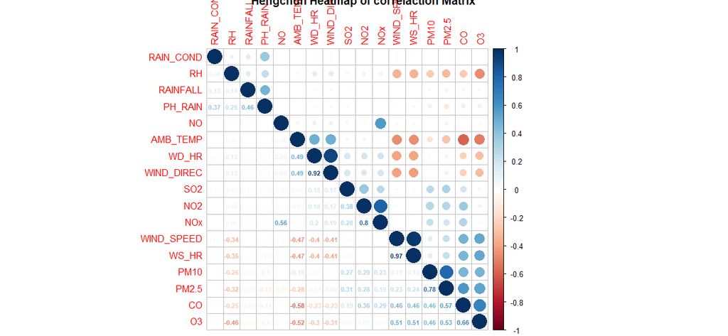

```r
corrplot(corr= correlations,order = "hclust",type="upper",tl.pos = "tp",tl.cex = 1)
corrplot(corr = correlations,add=TRUE, type="lower", method="number",order="hclust",diag=FALSE,tl.pos="n", cl.pos="n", tl.cex = 1,number.cex=0.7,title ="Hengchun Heatmap of correlaction Matrix")
```

```r
#相關性計算_Spring
correlations <- cor(Hengchun_spring[,-c(1,2,3, 12, 22, 23)], use="pairwise.complete.obs")  #date和PMLV不列入相關係數比較
dim(correlations)
```

```
## [1] 17 17
```

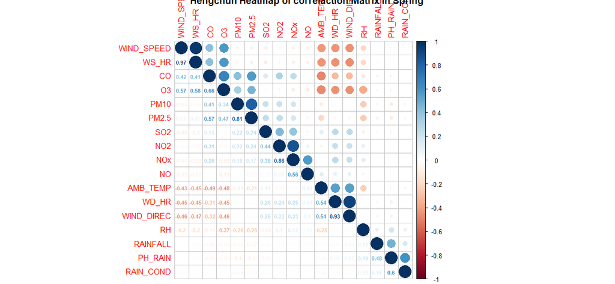

```r
corrplot(corr= correlations,order = "hclust",type="upper",tl.pos = "tp",tl.cex = 1)
corrplot(corr = correlations,add=TRUE, type="lower", method="number",order="hclust",diag=FALSE,tl.pos="n", cl.pos="n", tl.cex = 1,number.cex=0.7,title ="Hengchun Heatmap of correlaction Matrix in Spring")
```

```r
#相關性計算_Summer
correlations <- cor(Hengchun_summer[,-c(1,2,3, 12, 22, 23)], use="pairwise.complete.obs")  #date和PMLV不列入相關係數比較
dim(correlations)
```

```
## [1] 17 17
```

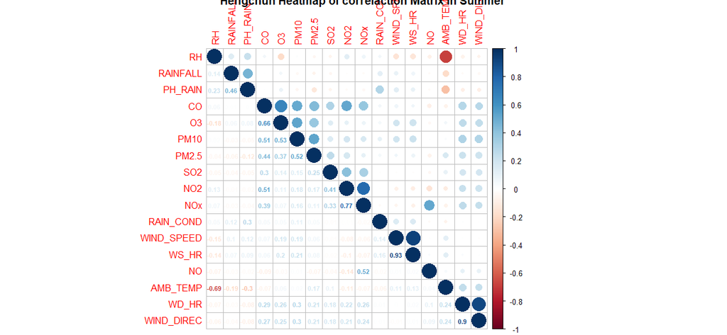

```r
corrplot(corr= correlations,order = "hclust",type="upper",tl.pos = "tp",tl.cex = 1)
corrplot(corr = correlations,add=TRUE, type="lower", method="number",order="hclust",diag=FALSE,tl.pos="n", cl.pos="n", tl.cex = 1,number.cex=0.7,title ="Hengchun Heatmap of correlaction Matrix in Summer")
```

```r
#相關性計算_Autumn
correlations <- cor(Hengchun_autumn[,-c(1,2, 3,12, 22, 23)], use="pairwise.complete.obs")  #date和PMLV不列入相關係數比較
dim(correlations)
```

```
## [1] 17 17
```

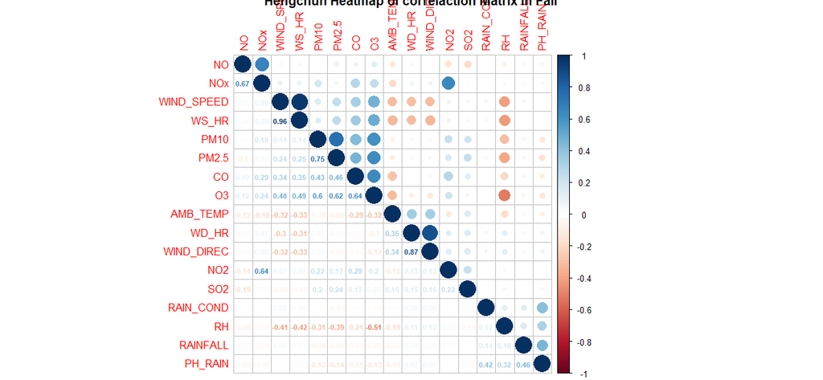

```r
corrplot(corr= correlations,order = "hclust",type="upper",tl.pos = "tp",tl.cex = 1)
corrplot(corr = correlations,add=TRUE, type="lower", method="number",order="hclust",diag=FALSE,tl.pos="n", cl.pos="n", tl.cex = 1,number.cex=0.7,title ="Hengchun Heatmap of correlaction Matrix in Fall")
```

```r
#相關性計算_Winter
correlations <- cor(Hengchun_winter[,-c(1,2, 3,12, 22, 23)], use="pairwise.complete.obs")  #date和PMLV不列入相關係數比較
dim(correlations)
```

```
## [1] 17 17
```

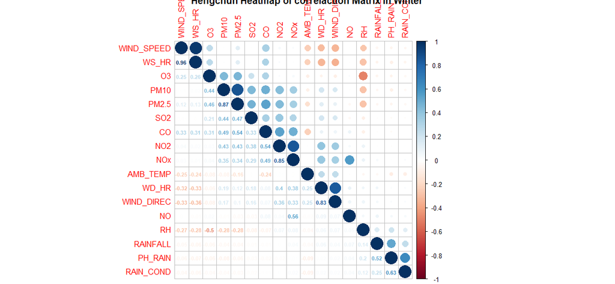

```r
corrplot(corr= correlations,order = "hclust",type="upper",tl.pos = "tp",tl.cex = 1)
corrplot(corr = correlations,add=TRUE, type="lower", method="number",order="hclust",diag=FALSE,tl.pos="n", cl.pos="n", tl.cex = 1,number.cex=0.7,title ="Hengchun Heatmap of correlaction Matrix in Winter")
```

# 6. 總結 Summary